[figure not shown]

*Transport Analytics Training Series - Last Revision: October 2022*

# Studying the London Underground

Now that we have experimented with a few small networks, we are ready to look at a more substantial dataset - the London Underground!

```python
import networkx as nx
import pandas as pd
import matplotlib.pyplot as plt
```

### Part 1 - Drawing the London Underground network

We have placed a simplified dataset of the LU network structure under the `data-london-underground` folder, which we will load using `pandas`.

```python
stations = pd.read_csv('data-london-underground/lu_stations.csv')
stations
```

|  | id | latitude | longitude | name | zone |
| --- | --- | --- | --- | --- | --- |
| 0 | 1 | 51.5028 | -0.2801 | Acton Town | 3.0 |
| 1 | 8 | 51.5653 | -0.1353 | Archway | 2.5 |
| 2 | 9 | 51.6164 | -0.1331 | Arnos Grove | 4.0 |
| 3 | 10 | 51.5586 | -0.1059 | Arsenal | 2.0 |
| 4 | 11 | 51.5226 | -0.1571 | Baker Street | 1.0 |
| ... | ... | ... | ... | ... | ... |
| 139 | 296 | 51.5120 | -0.2239 | White City | 2.0 |
| 140 | 297 | 51.5492 | -0.2215 | Willesden Green | 2.5 |
| 141 | 303 | 51.5975 | -0.1097 | Wood Green | 3.0 |
| 142 | 301 | 51.6070 | 0.0341 | Woodford | 4.0 |
| 143 | 302 | 51.6179 | -0.1856 | Woodside Park | 4.0 |

144 rows × 5 columns

This is about half the number of stations compared to the real world network. We did that in order to keep things simple for the purposes of this analysis.

```python
links = pd.read_csv('data-london-underground/lu_links.csv')
links
```

|  | station1 | station2 | line | time |
| --- | --- | --- | --- | --- |
| 0 | 1 | 234 | 10 | 4 |
| 1 | 1 | 265 | 10 | 4 |
| 2 | 8 | 124 | 9 | 3 |
| 3 | 8 | 264 | 9 | 2 |
| 4 | 9 | 31 | 10 | 3 |
| ... | ... | ... | ... | ... |
| 164 | 257 | 258 | 9 | 2 |
| 165 | 261 | 302 | 9 | 3 |
| 166 | 266 | 303 | 10 | 2 |
| 167 | 279 | 285 | 7 | 2 |
| 168 | 288 | 302 | 9 | 1 |

169 rows × 4 columns

No surprises here - let's now convert these into a graph.

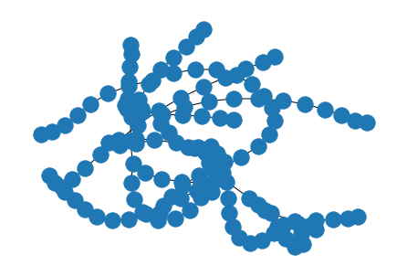

```python
G = nx.Graph()
G.add_nodes_from(stations['id'])
G.add_edges_from(list(zip(links['station1'], links['station2'])))

nx.draw(G)
```

We have such a large number of nodes, and this ends up being a very busy graph. We can amend the way that the nodes are plotted, so that it looks a bit nicer. We can do this using the `node_size` parameter.

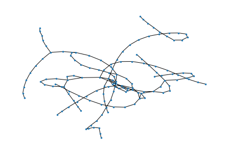

```python
nx.draw(G, node_size = 6)
```

But it remains a bit difficult to see - what if we could we make it a bit bigger?

This is possible using a few more advanced `matplotlib` features. You see, in every new cell we are creating a new instance of a `matplotlib` chart. Thanks to the `pyplot` library within `matplotlib`, the chart creation is quite similar to the one found in Matlab - so some concepts might look familiar.

To modify the size of the figure, we simply have to initialise the chart ourselves, usiing the `plt.figure()` command, and then specify its size using the `figsize` command.

If you want to more help with the transition from Matlab to Python, you can read [this very helpful guide](https://www.enthought.com/wp-content/uploads/Enthought-MATLAB-to-Python-White-Paper.pdf), or follow this [DataCamp course](https://learn.datacamp.com/courses/python-for-matlab-users).

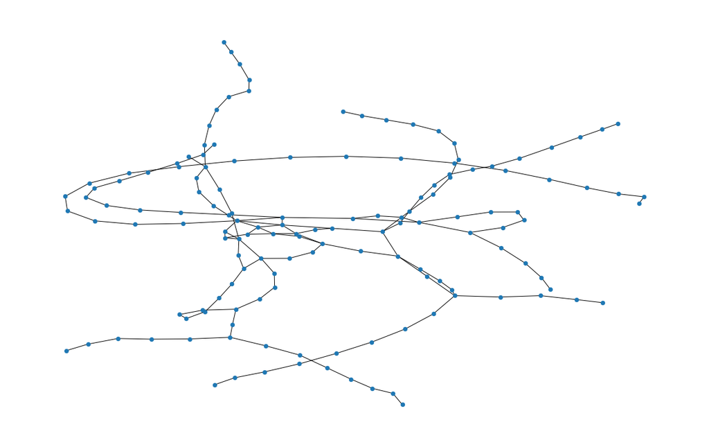

```python
plt.figure(figsize=(16,10))
nx.draw(G, node_size = 40)
```

Much better, but now that we have a better look at it, this certainly doesn't look anything like the London Tube.

Ah! But of course! We forgot to add the coordinates.

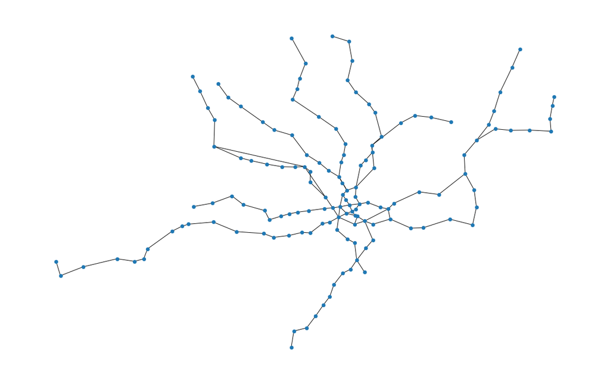

```python
plt.figure(figsize=(16,10))

coords = list(zip(stations['longitude'],stations['latitude']))
pos = dict(zip(stations['id'], coords))
nx.draw(G,pos,node_size = 40)
```

### Part 2 - Extraction of network subgraphs

What if we wanted to only illustrate the subgraph of the network that lies within Zones 1?

We can do that easily using using the `zone` column in the `stations` dataframe - note that the authors of that list chose use "half" values to denote stations that lie in two zones at the same time. Therefore `Archway` station is described in being in zone `2.5`, when in official maps it is placed on the boundaries of zones 2 and 3.

Therefore, if we want to obtain all the nodes that are found in zone 1, we would really have to obtain the stations with a `zone` value of `<2` - it we used `<=1` to filter the list, we would have excluded stations that lie in the zone boundary, such as Earls Court.

```python
stations_z1 = pd.read_csv('data-london-underground/lu_stations.csv')
stations_z1 = stations_z1[stations_z1['zone']<2]
len(stations_z1)
```

```
36
```

We filtered the stations using a condition applied on the `zone` columnn. This effectively says:

"Look at the `zone` column within the `stations_z1` dataframe, and select the rows where its value is less than 2. Now return a new dataframe, that contains only these rows".

To do this, we first create a list of all "allowed" node IDs. We then filter the list be exluding any link whose endpoints do not belong in Zone 1.

```python
allowed_stations = list(stations_z1['id'])

links_z1 = pd.read_csv('data-london-underground/lu_links.csv')
links_z1 = links_z1.loc[links_z1['station1'].isin(allowed_stations)]
len(links_z1)
```

```
57
```

We have now the list down to 57 nodes, which have an allowed station in the `station1` column. Let's now apply the filter to `station2`.

```python
links_z1 = links_z1.loc[links_z1['station2'].isin(allowed_stations)]
len(links_z1)
```

```
54
```

Let's now visualise the part of the network:

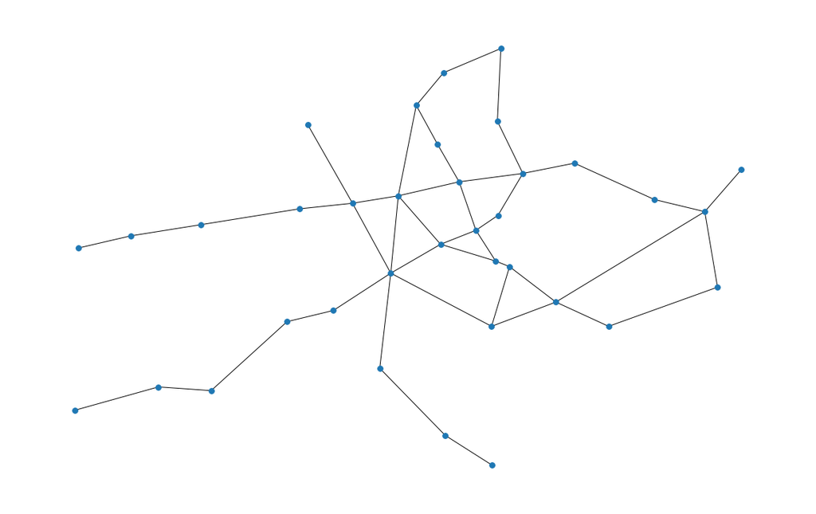

```python
G_z1 = nx.Graph()
G_z1.add_nodes_from(stations_z1['id'])
G_z1.add_edges_from(list(zip(links_z1['station1'], links_z1['station2'])))

plt.figure(figsize=(16,10))
coords = list(zip(stations_z1['longitude'],stations_z1['latitude']))
pos = dict(zip(stations_z1['id'], coords))
nx.draw(G_z1, pos, node_size = 60)
```

### Part 3 - Obtaining centrality metrics

We can now add a list of our centralities.

I am going to use a `lambda` function to add station names into a column, based on dictionary and the value of the `ID` column. There are much easier ways to achieve this, but I wanted to take this opportunity to show you the `lambda` feature in action.

```python
dict_names = dict(zip(stations['id'],stations['name']))
```

```python
centralities = pd.DataFrame()
centralities['ID'] = G.nodes()
centralities['Names'] = centralities["ID"].map(lambda x:dict_names[x])
centralities['degree_centr'] = nx.degree_centrality(G).values()
centralities['closeness_centr'] = nx.closeness_centrality(G).values()
centralities['betweenness_centr'] = nx.betweenness_centrality(G).values()
centralities['eigenvector_centr'] = nx.eigenvector_centrality(G).values()
```

Let us now obtain our "Top 10" lists.

```python
centralities.sort_values(by='degree_centr', ascending=False).head(10).reset_index()[['Names','degree_centr']]
```

|  | Names | degree_centr |
| --- | --- | --- |
| 0 | Green Park | 0.041958 |
| 1 | Oxford Circus | 0.034965 |
| 2 | Waterloo | 0.034965 |
| 3 | Leicester Square | 0.027972 |
| 4 | Bond Street | 0.027972 |
| 5 | Euston | 0.027972 |
| 6 | Finsbury Park | 0.027972 |
| 7 | Piccadilly Circus | 0.027972 |
| 8 | Stockwell | 0.027972 |
| 9 | Tottenham Court Road | 0.027972 |

```python
centralities.sort_values(by='closeness_centr', ascending=False).head(10).reset_index()[['Names','closeness_centr']]
```

|  | Names | closeness_centr |
| --- | --- | --- |
| 0 | Green Park | 0.135417 |
| 1 | Oxford Circus | 0.133023 |
| 2 | Bond Street | 0.129882 |
| 3 | Westminster | 0.127565 |
| 4 | Warren Street | 0.126102 |
| 5 | Piccadilly Circus | 0.125000 |
| 6 | Tottenham Court Road | 0.123596 |
| 7 | Hyde Park Corner | 0.123064 |
| 8 | Victoria | 0.122118 |
| 9 | Waterloo | 0.122014 |

```python
centralities.sort_values(by='betweenness_centr', ascending=False).head(10).reset_index()[['Names','betweenness_centr']]
```

|  | Names | betweenness_centr |
| --- | --- | --- |
| 0 | Green Park | 0.483804 |
| 1 | Euston | 0.372402 |
| 2 | Oxford Circus | 0.340179 |
| 3 | Warren Street | 0.307614 |
| 4 | Bond Street | 0.305722 |
| 5 | Bank & Monument | 0.282445 |
| 6 | Waterloo | 0.250051 |
| 7 | King's Cross St. Pancras | 0.248839 |
| 8 | Camden Town | 0.240914 |
| 9 | Hyde Park Corner | 0.221609 |

```python
centralities.sort_values(by='eigenvector_centr', ascending=False).head(10).reset_index()[['Names','eigenvector_centr']]
```

|  | Names | eigenvector_centr |
| --- | --- | --- |
| 0 | Green Park | 0.425429 |
| 1 | Oxford Circus | 0.419025 |
| 2 | Piccadilly Circus | 0.368797 |
| 3 | Bond Street | 0.286223 |
| 4 | Leicester Square | 0.265054 |
| 5 | Tottenham Court Road | 0.258158 |
| 6 | Charing Cross | 0.219205 |
| 7 | Westminster | 0.200704 |
| 8 | Warren Street | 0.171072 |
| 9 | Embankment | 0.155901 |

The overwhelming message here is that Green Park is definitely important!

### Part 4 - Generation of centrality visualisations

Let's now visualise these values:

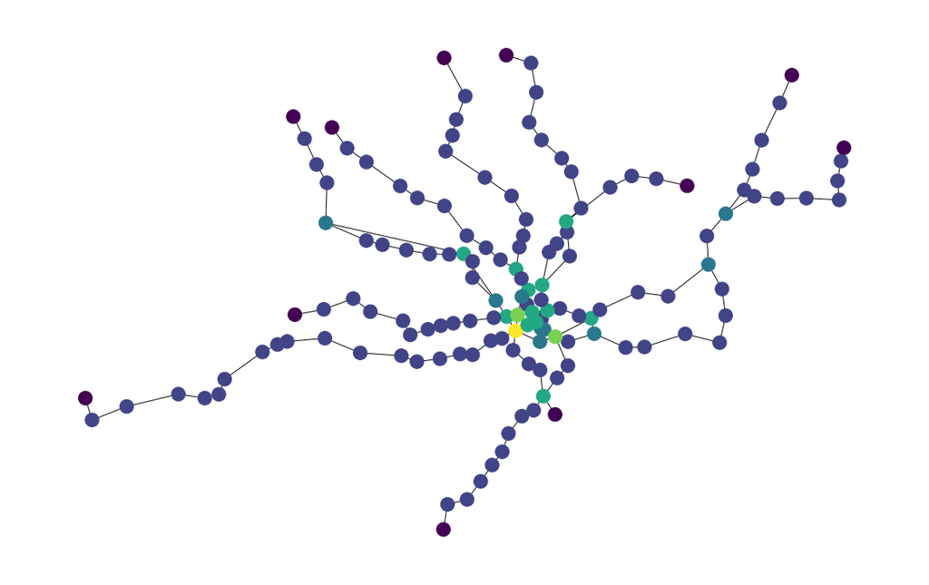

```python
plt.figure(figsize=(16,10))
coords = list(zip(stations['longitude'],stations['latitude']))
pos = dict(zip(stations['id'], coords))
nx.draw(G, pos, with_labels = False, node_color = list(centralities['degree_centr']))
```

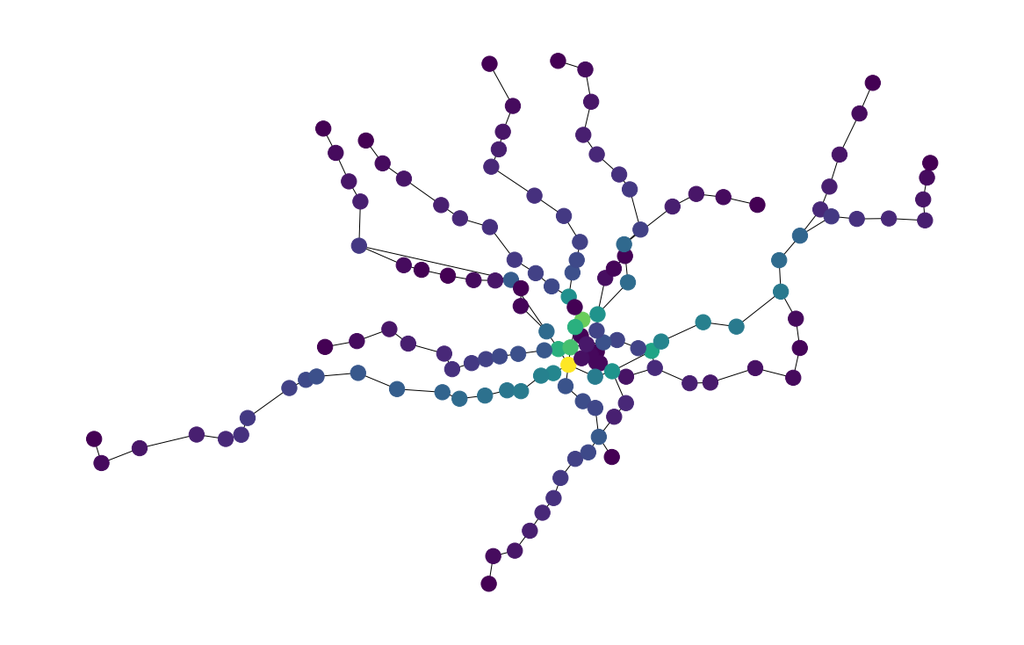

```python
plt.figure(figsize=(16,10))
coords = list(zip(stations['longitude'],stations['latitude']))
pos = dict(zip(stations['id'], coords))
nx.draw(G, pos, with_labels = False, node_color = list(centralities['betweenness_centr']))
```

### Part 5 - Using K-Means to obtain zones

At this point we will apply the K-Means algorithm approach in order to split the network into zones. I would strongly advise that you pause this notebook for the time being, and instead have a look at the next one in this serios (2.4 - Kmeans clustering), which introduces the fundamentals of this method in more detail.

You can return back to this notebook once you had a look on that.

To proceed, we import the `KMeans` cluster from `sklearn` and the `numpy` package.

```python
from sklearn.cluster import KMeans
import numpy as np
```

The `Kmeans` algorithm can work with any dataset - in our case we will simply apply it to an array of the station coordinates.

```python
coord = np.array(list(zip(stations['longitude'],stations['latitude'])))
```

```python
model = KMeans(n_clusters=10)
model.fit(coord)
clust_pred = model.predict(coord)
```

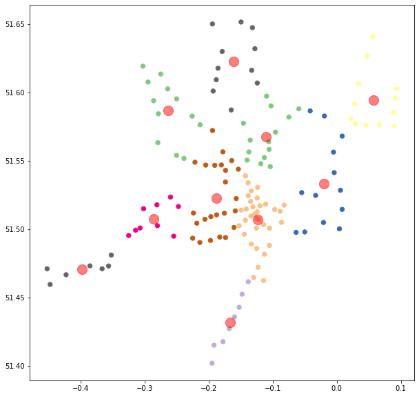

```python
plot_size   = 20
plot_width  = 10
plot_height = 10

params = {'legend.fontsize': 'large',
          'figure.figsize': (plot_width,plot_height),
          'axes.labelsize': plot_size,
          'axes.titlesize': plot_size,
          'xtick.labelsize': plot_size*0.5,
          'ytick.labelsize': plot_size*0.50,
          'axes.titlepad': 25}
plt.rcParams.update(params)

plt.scatter(coord[:, 0],
            coord[:, 1],
            c = clust_pred,
            s=plot_size*2,
            cmap='Accent')

centers = model.cluster_centers_

plt.scatter(centers[:, 0],
            centers[:, 1],
            c = 'red',
            s=plot_size*10,
            alpha=0.5);
```

Next, we are going to use the `KElbowVisualizer` from the `yellowbrick` package to pick a number of clusters. We first need to make sure that it is installed using pip:

```python
!pip install yellowbrick
```

```
     |████████████████████████████████| 282 kB 3.4 MB/s eta 0:00:01
```

We are ready to go.

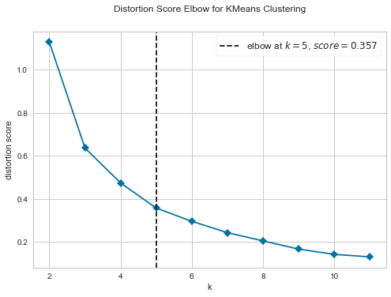

```python
from yellowbrick.cluster import KElbowVisualizer

visualizer = KElbowVisualizer(model, k=(2,12),timings=False)
visualizer.fit(coord)   # Fit the data to the visualizer
visualizer.show()       # Finalize and render the figure
```

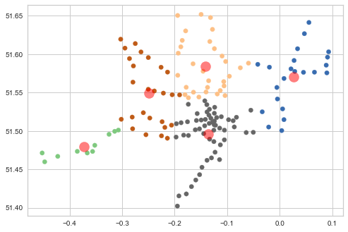

```python
model = KMeans(n_clusters=5)
model.fit(coord)
clust_pred = model.predict(coord)

plt.scatter(coord[:, 0],
            coord[:, 1],
            c = clust_pred,
            s=plot_size*2,
            cmap='Accent')

centers = model.cluster_centers_

plt.scatter(centers[:, 0],
            centers[:, 1],
            c = 'red',
            s=plot_size*10,
            alpha=0.5);
```

These look relalatively sensible upon first sight. Let us now store the cluster memberships into the `stations` dataframe.

```python
stations['cluster'] = clust_pred
stations
```

|  | id | latitude | longitude | name | zone | cluster |
| --- | --- | --- | --- | --- | --- | --- |
| 0 | 1 | 51.5028 | -0.2801 | Acton Town | 3.0 | 3 |
| 1 | 8 | 51.5653 | -0.1353 | Archway | 2.5 | 1 |
| 2 | 9 | 51.6164 | -0.1331 | Arnos Grove | 4.0 | 1 |
| 3 | 10 | 51.5586 | -0.1059 | Arsenal | 2.0 | 1 |
| 4 | 11 | 51.5226 | -0.1571 | Baker Street | 1.0 | 4 |
| ... | ... | ... | ... | ... | ... | ... |
| 139 | 296 | 51.5120 | -0.2239 | White City | 2.0 | 3 |
| 140 | 297 | 51.5492 | -0.2215 | Willesden Green | 2.5 | 3 |
| 141 | 303 | 51.5975 | -0.1097 | Wood Green | 3.0 | 1 |
| 142 | 301 | 51.6070 | 0.0341 | Woodford | 4.0 | 2 |
| 143 | 302 | 51.6179 | -0.1856 | Woodside Park | 4.0 | 1 |

144 rows × 6 columns

## Part 6 - Demand Analysis

We are lucky enough to have an indication of travel demand patterns in the Night Tube, thanks to the Oyster data that were made available released from Transport for London under their Rolling Origin and Demand Survey (RODS). The entire set of data can be found at:

http://crowding.data.tfl.gov.uk

Before going any further let's load the demand file.

```python
demand = pd.read_csv('data-london-underground/lu_od.csv')
demand
```

|  | origin_id | dest_id | origin_name | dest_name | demand |
| --- | --- | --- | --- | --- | --- |
| 0 | 1 | 8 | Acton Town | Archway | 0 |
| 1 | 1 | 9 | Acton Town | Arnos Grove | 1 |
| 2 | 1 | 10 | Acton Town | Arsenal | 0 |
| 3 | 1 | 11 | Acton Town | Baker Street | 0 |
| 4 | 1 | 12 | Acton Town | Balham | 1 |
| ... | ... | ... | ... | ... | ... |
| 20214 | 43 | 233 | Canning Town | Southwark | 15 |
| 20215 | 43 | 23 | Canning Town | Bermondsey | 17 |
| 20216 | 43 | 41 | Canning Town | Canada Water | 92 |
| 20217 | 43 | 183 | Canning Town | North Greenwich | 56 |
| 20218 | 43 | 42 | Canning Town | Canary Wharf | 47 |

20219 rows × 5 columns

We can see in the above that demands are provided in an "directional" manner - as a flow of customers from one node to another.

To make a better sense of the dataset, we will seek to aggregate these flows into a sum of departures and arrivals for each station.

To do this, we start by creatign two empty dictionaries - to store the total flows. The initial flow value for each station will be zero, and we will be adding flows to the correct place in the dictionary one by one.

We set up these dictionaries by zipping a list of station IDs and an empty array of zeroes - this should be exactly as long as the list of stations. We can do this using the `np.zeros(len(stations))` command.

```python
dict_from = dict(zip(stations['id'],np.zeros(len(stations))))
dict_to = dict(zip(stations['id'],np.zeros(len(stations))))
```

In the next step, we will be going into each node in our set one by one, and we will be summing the flow values on our demand table for the current node, with respect to the `origin_id` and `dest_id` columns, respectively.

```python
for node in dict_from:
    dict_from[node] = demand.loc[demand['origin_id'] == node, 'demand'].sum()

for node in dict_to:
    dict_to[node] = demand.loc[demand['dest_id'] == node, 'demand'].sum()
```

We can now store these values into our `stations` dataframe.

```python
stations['tot_departures'] = dict_from.values()
stations['tot_arrivals'] = dict_to.values()
stations
```

|  | id | latitude | longitude | name | zone | cluster | tot_departures | tot_arrivals |
| --- | --- | --- | --- | --- | --- | --- | --- | --- |
| 0 | 1 | 51.5028 | -0.2801 | Acton Town | 3.0 | 3 | 119 | 603 |
| 1 | 8 | 51.5653 | -0.1353 | Archway | 2.5 | 1 | 252 | 919 |
| 2 | 9 | 51.6164 | -0.1331 | Arnos Grove | 4.0 | 1 | 76 | 515 |
| 3 | 10 | 51.5586 | -0.1059 | Arsenal | 2.0 | 1 | 40 | 350 |
| 4 | 11 | 51.5226 | -0.1571 | Baker Street | 1.0 | 4 | 1586 | 887 |
| ... | ... | ... | ... | ... | ... | ... | ... | ... |
| 139 | 296 | 51.5120 | -0.2239 | White City | 2.0 | 3 | 474 | 407 |
| 140 | 297 | 51.5492 | -0.2215 | Willesden Green | 2.5 | 3 | 187 | 1091 |
| 141 | 303 | 51.5975 | -0.1097 | Wood Green | 3.0 | 1 | 315 | 1264 |
| 142 | 301 | 51.6070 | 0.0341 | Woodford | 4.0 | 2 | 51 | 636 |
| 143 | 302 | 51.6179 | -0.1856 | Woodside Park | 4.0 | 1 | 48 | 578 |

144 rows × 8 columns

Let us now obtain our Top 10 tables for most departures and arrivals, in the usual way.

```python
stations.sort_values(by='tot_departures', ascending=False).head(10).reset_index()[['name', 'tot_departures']]
```

|  | name | tot_departures |
| --- | --- | --- |
| 0 | Leicester Square | 9384 |
| 1 | Oxford Circus | 7996 |
| 2 | Tottenham Court Road | 7248 |
| 3 | Piccadilly Circus | 6413 |
| 4 | King's Cross St. Pancras | 5667 |
| 5 | Green Park | 5427 |
| 6 | London Bridge | 5362 |
| 7 | Bank & Monument | 5145 |
| 8 | North Greenwich | 4732 |
| 9 | Holborn | 3833 |

No surprises here - Leicester Squere, Oxford Circus, Tottenham Court Road and Picadilly Circus enclose London's Soho district. The other stations in the list are also quite sensivle.

```python
stations.sort_values(by='tot_arrivals', ascending=False).head(10).reset_index()[['name', 'tot_arrivals']]
```

|  | name | tot_arrivals |
| --- | --- | --- |
| 0 | Waterloo | 6890 |
| 1 | Stratford | 5834 |
| 2 | London Bridge | 5105 |
| 3 | Victoria | 5008 |
| 4 | King's Cross St. Pancras | 4893 |
| 5 | Canada Water | 4149 |
| 6 | Brixton | 3888 |
| 7 | Canning Town | 3629 |
| 8 | Finsbury Park | 3168 |
| 9 | Liverpool Street | 2932 |

The majority of stations in the list of most arrivals are train stations - this is to be expected as well.

How about the top flows between specific stations?

```python
demand.sort_values(by='demand', ascending=False).head(10).reset_index()[['origin_name', 'dest_name','demand']]
```

|  | origin_name | dest_name | demand |
| --- | --- | --- | --- |
| 0 | Bank and Monument | Waterloo LU | 810 |
| 1 | Oxford Circus | Victoria LU | 740 |
| 2 | Leicester Square | Waterloo LU | 737 |
| 3 | London Bridge LU | Canada Water | 609 |
| 4 | Piccadilly Circus | Waterloo LU | 559 |
| 5 | North Greenwich | Waterloo LU | 548 |
| 6 | Leicester Square | King's Cross St. Pancras | 537 |
| 7 | Oxford Circus | Brixton LU | 535 |
| 8 | North Greenwich | Stratford | 525 |
| 9 | Tottenham Court Road | Stratford | 524 |

Now we want to obtain the aggregate demands between zones. We can do this using the code below.

You have seen quite a lot of these commands - can you describe what is happening in each line?

*Note: you might see a warning - don't worry about it, the code works well.*

```python
dict_zones = dict(zip(stations['id'],stations['cluster']))

demand_filt = demand[['origin_id','dest_id','demand']]

demand_filt['origin_cluster'] = demand_filt["origin_id"].map(lambda x:dict_zones[x])
demand_filt['dest_cluster'] = demand_filt["dest_id"].map(lambda x:dict_zones[x])

demand_filt=demand_filt[['origin_cluster','dest_cluster','demand']]
demand_filt.groupby(['origin_cluster','dest_cluster'])['demand'].sum().reset_index()

demand_filt
```

[output not shown]

|  | origin_cluster | dest_cluster | demand |
| --- | --- | --- | --- |
| 0 | 3 | 1 | 0 |
| 1 | 3 | 1 | 1 |
| 2 | 3 | 1 | 0 |
| 3 | 3 | 4 | 0 |
| 4 | 3 | 4 | 1 |
| ... | ... | ... | ... |
| 20214 | 2 | 4 | 15 |
| 20215 | 2 | 4 | 17 |
| 20216 | 2 | 4 | 92 |
| 20217 | 2 | 2 | 56 |
| 20218 | 2 | 2 | 47 |

20219 rows × 3 columns

The above table gives us a line for each station, with columns for the origin and destination clusters, but a demand value for each individual station pair.

We can group them into individual clusters using the `groupby()` command.

```python
demand_filt.groupby(['origin_cluster','dest_cluster'])['demand'].sum().reset_index()
```

|  | origin_cluster | dest_cluster | demand |
| --- | --- | --- | --- |
| 0 | 0 | 0 | 602 |
| 1 | 0 | 1 | 80 |
| 2 | 0 | 2 | 65 |
| 3 | 0 | 3 | 172 |
| 4 | 0 | 4 | 318 |
| 5 | 1 | 0 | 101 |
| 6 | 1 | 1 | 3618 |
| 7 | 1 | 2 | 1242 |
| 8 | 1 | 3 | 1069 |
| 9 | 1 | 4 | 5565 |
| 10 | 2 | 0 | 89 |
| 11 | 2 | 1 | 952 |
| 12 | 2 | 2 | 5672 |
| 13 | 2 | 3 | 831 |
| 14 | 2 | 4 | 6716 |
| 15 | 3 | 0 | 319 |
| 16 | 3 | 1 | 1009 |
| 17 | 3 | 2 | 972 |
| 18 | 3 | 3 | 1878 |
| 19 | 3 | 4 | 3383 |
| 20 | 4 | 0 | 1729 |
| 21 | 4 | 1 | 21237 |
| 22 | 4 | 2 | 18631 |
| 23 | 4 | 3 | 12432 |
| 24 | 4 | 4 | 57638 |

And we are done!